# Raport 4

Michal Burdukiewicz, Piotr Sobczyk

20 lipca 2015

# Aplikacja

https://michbur.shinyapps.io/propertyapp

# Encoding distance

Encoding distance między kodowaniami A i B to liczba aminokwasów jakie trzeba przeniść w obrębie kodowania A, aby uzyskać kodowanie B.

Na przykład:

Kodowanie A.

| Names | Elements |
| --- | --- |
| 1 | a, b, c |
| 2 | d, e |

Kodowanie B.

| Names | Elements |
| --- | --- |
| 1 | a, b |
| 2 | d, e, c |

Encoding distance między A i B wynosi 1, ponieważ wymaga przeniesienia między grupami tylko jednego elementu (c).

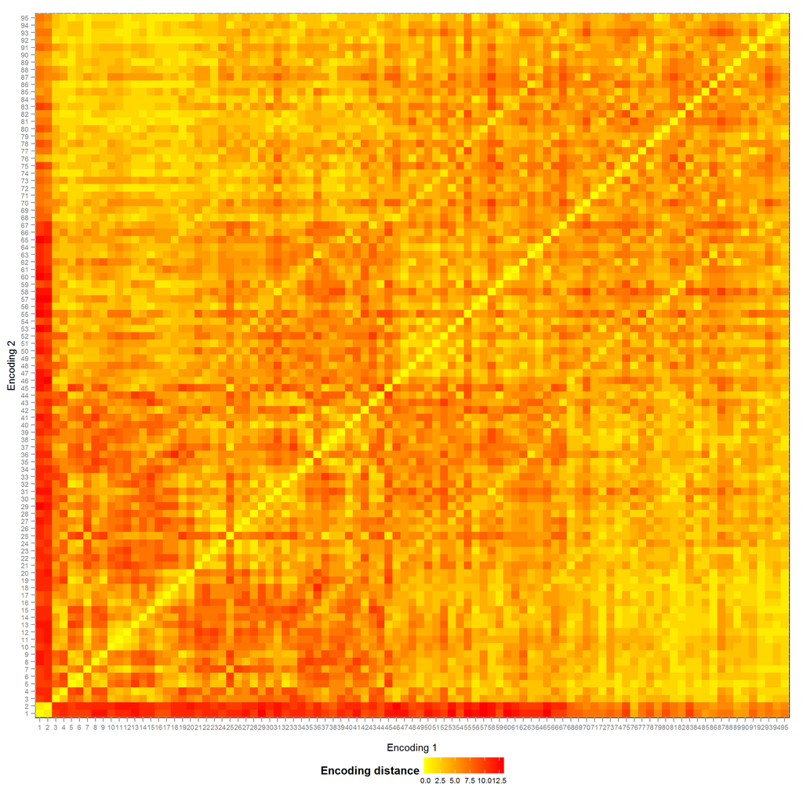

Na powyższej figurze przedstawiono dystance między użytymi kodowaniami. Kodowania 1 i 2, oparte na literaturze, najbardziej odróżniają się od kodowań wygenerowanych na podstawie cech z bazy AAIndex.

# Encoding distance a AUC

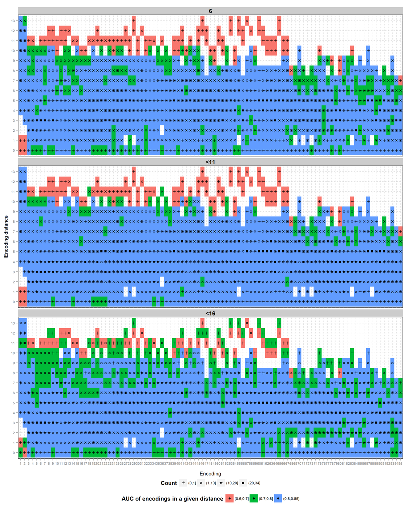

Dla każdego kodowania X inne kodowania podzielono według ich encoding distance w stosunku do kodowania X. Symbolem oznaczono liczbę kodowań o danym encoding distance, a kolorem średnie AUC opartych na nich predykcji.

Dla zbioru treningowego zawierającego peptydy krótsze niż 16 aminokwasów pojawia się dużo więcej “przeciętnych” kodowań (z przedziału (0.7 do 0.8)

Kodowania z najwyższą średnią wartością AUC.

| Training length | Encoding ID | Mean AUC | Mean Specificity | Mean Sensitivity | Number of groups |
| --- | --- | --- | --- | --- | --- |
| 6 | 86 | 0.8195 | 0.8682 | 0.5675 | 6 |
| <11 | 79 | 0.8341 | 0.6980 | 0.8198 | 6 |
| <16 | 91 | 0.8414 | 0.5352 | 0.9165 | 6 |

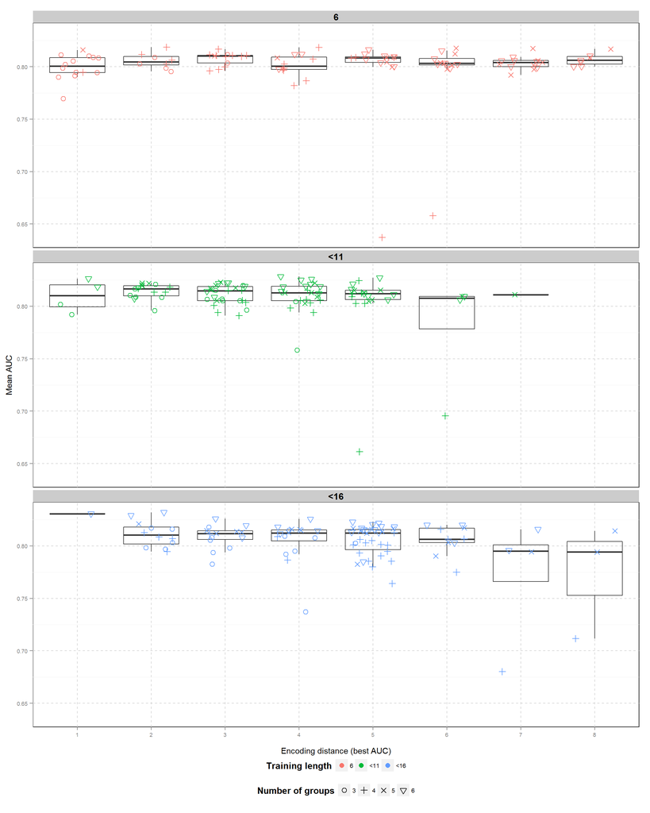

Oś X - encoding distance od kodowania z najlepszym AUC.  
Oś Y - średnia wartość AUC dla kodowania.

Wyniki testu korelacji Pearsona.

| Training length | Correlation coefficient | p-value |
| --- | --- | --- |
| 6 | -0.0368 | 0.7235 |
| <11 | -0.2376 | 0.0204 |
| <16 | -0.3608 | 0.0003 |

# Encoding distance a Sensitivity/Specificity

Kodowania wybrane jako punkty odniesienia.

| Training length | Encoding ID | Mean AUC | Mean Specificity | Mean Sensitivity | Number of groups |
| --- | --- | --- | --- | --- | --- |
| 6 | 6 | 0.7955 | 0.8221 | 0.6181 | 3 |
| 6 | 45 | 0.8183 | 0.9014 | 0.5038 | 4 |
| <11 | 2 | 0.6615 | 0.4304 | 0.8307 | 4 |
| <11 | 15 | 0.8088 | 0.8329 | 0.6060 | 3 |
| <16 | 16 | 0.8162 | 0.7477 | 0.7374 | 3 |
| <16 | 87 | 0.8320 | 0.5186 | 0.9195 | 6 |

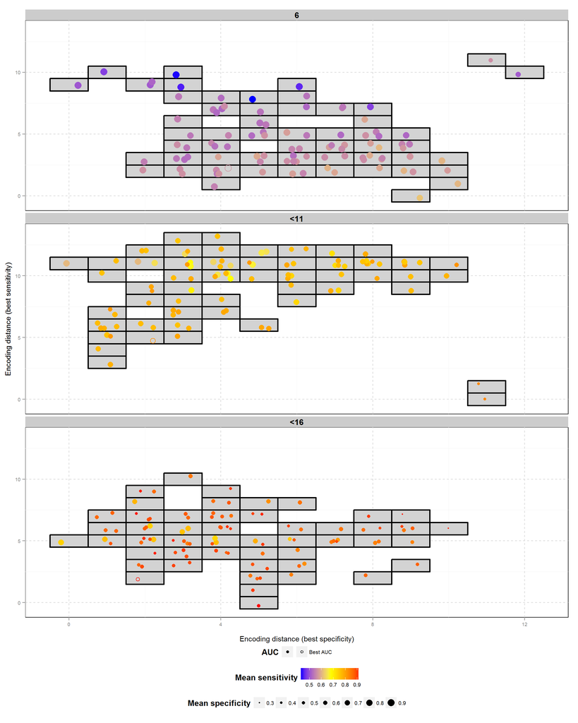

Oś X przedstawia encoding distance od kodowania z najlepszą specificity dla danej długości peptydów w zbiorze uczącym, a oś Y encoding distance od kodowania z najlepszą sensitivity. Kolor i wielkość punktu oznaczają odpowiednio sensitivity i specificity danego kodowania. Ponieważ wiele punktów może mieć takie same współrzędne X i Y, ich położenie jest losowo rozłożone w obrębie danej lokalizacji oznaczonej czarną linią.

Klasyfikatory uczone na heksapeptydach charakteryzują się najlepszą specificity, a na długich peptydach najlepszą sensitivity.

W przypadku klasyfikatorów uczonych na dekapeptydach, wyróżnia się frakcja klasyfikatorów z dobrą specificity i sensitivity mimo ich dużej odległości od początku układu współrzędnych. Dodatkowo, grupy klasyfikatorów o identycznym położeniu dla dekaptydów są niejednorodne.

Kodowanie z najlepszym AUC zawsze jest blisko początku układu współrzędnych.

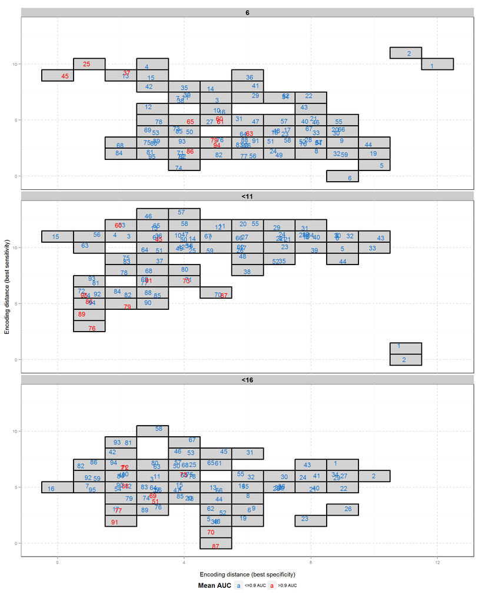

Na powyższym wykresie kolor nazwy kodowania oznacza jego AUC. >0.9 AUC oznacza, że wartość AUC danego kodowania znajduje się w kwantylu rzędu 0.9.

Dla heksamerów jedne z najlepszych AUC mają również kodowanie odległe od kodowania o najlepszym sensitivity.